# Self-Driving Car Engineer Nanodegree

## Step 3: Test a Model on New Images

To give yourself more insight into how your model is working, download at least five pictures of German traffic signs from the web and use your model to predict the traffic sign type.

You may find `signnames.csv` useful as it contains mappings from the class id (integer) to the actual sign name.

### Load and Output the Images

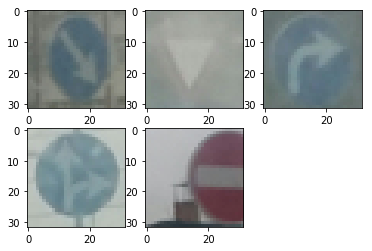

```python
# Load 5 images from img folder with filenames test0.bmp - test5.bmp
# array my_images contains the loaded RGB images
#import the required libraries
import numpy as np
import cv2
import matplotlib.pyplot as plt
%matplotlib inline

my_images = np.zeros((5, 32, 32, 3),dtype=np.uint8)
fig = plt.figure()
for i in range(5):
    name = 'img/test0'+str(i)+'.bmp'
    img = cv2.imread(name)
    img = cv2.cvtColor(img, cv2.COLOR_BGR2RGB)
    my_images[i,:,:,:]=img
    subplot = fig.add_subplot(2,3,i+1)
    subplot.imshow(img)
```

```python
#Define the new arrays to store the preprossed data
converted_my_images = np.zeros((len(my_images), 32, 32, 3),dtype=np.uint8)
#Preporocessing the data
for i in range(len(my_images)):
    converted_my_images[i,:,:,:] = imgConvertion(my_images[i,:,:,:])
converted_my_labels = np.zeros((len(converted_my_images), n_classes),dtype=np.uint8)
```

### Predict the Sign Type for Each Image

```python
#import the required libraries
import tensorflow as tf

with tf.Session() as sess:
    # load the saved model
    loader = tf.train.import_meta_graph('TrafficSignalPredictModel.ckpt.meta')
    loader.restore(sess, tf.train.latest_checkpoint('./'))

    softmaxs, softmaxce, logits, predictions = sess.run([softmax, softmax_cross_entropy, y_conv,
prediction],feed_dict={x: converted_my_images, y: converted_my_labels, keep_prob: 1.0})

print ('Predictions:')
print (predictions)
print ('Correct labels:')
print ('[38 13 33 36 17]')
```

```
Predictions:
[38 13 33 36 25]
Correct labels:
[38 13 33 36 17]
```

### Analyze Performance

```python
### Calculating the accuracy for these 5 new images.

#As the model predicted 4 out of 5 signs correctly, it's 80% accurate on these new images.
#one image was not pridicted because its truncated
```

### Output Top 5 Softmax Probabilities For Each Image Found on the Web

```
TopKV2(values=array([  9.99374688e-01,   4.77650785e-04,   1.19412296e-04,
         2.10176058e-05,   3.18288835e-06], dtype=float32), indices=array([38, 34, 36, 35, 13], dtype=int32))
```

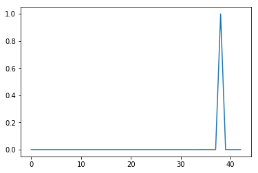

```python
# Top 5 Softmax Probabilities For Image 1:

plt.plot(softmaxs[0])
import tensorflow as tf
with tf.Session() as sess:
    topk = sess.run(tf.nn.top_k((tf.constant(softmaxs[0])), k=5))
print (topk)
```

```
TopKV2(values=array([ 0.741153  ,  0.05419565,  0.04074874,  0.02718007,  0.02697666], dtype=float32), indices=array([13, 12, 18, 36, 35], dtype=int32))
```

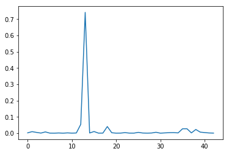

```python
# Top 5 Softmax Probabilities For Image 2:
plt.plot(softmaxs[1])
import tensorflow as tf
with tf.Session() as sess:
    topk = sess.run(tf.nn.top_k((tf.constant(softmaxs[1])), k=5))
print (topk)
```

```
TopKV2(values=array([  9.69856739e-01,   2.20742244e-02,   6.42209128e-03,
         6.44695247e-04,   4.02367965e-04], dtype=float32), indices=array([33, 35, 34, 13, 11], dtype=int32))
```

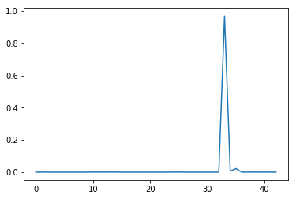

```python
# Top 5 Softmax Probabilities For Image 3:

plt.plot(softmaxs[2])
import tensorflow as tf
with tf.Session() as sess:
    topk = sess.run(tf.nn.top_k((tf.constant(softmaxs[2])), k=5))
print (topk)
```

```
TopKV2(values=array([  9.32844639e-01,   3.42899524e-02,   2.07207780e-02,
         9.57800541e-03,   8.54583748e-04], dtype=float32), indices=array([36, 38, 40, 18, 34], dtype=int32))
```

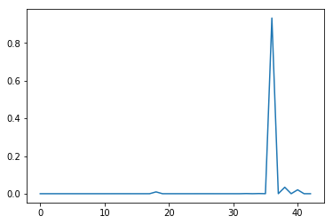

```python
# Top 5 Softmax Probabilities For Image 4:
plt.plot(softmaxs[3])
import tensorflow as tf
with tf.Session() as sess:
    topk = sess.run(tf.nn.top_k((tf.constant(softmaxs[3])), k=5))
print (topk)
```

```
TopKV2(values=array([ 0.98211306,  0.00755844,  0.00318464,  0.00210517,  0.00109133], dtype=float32), indices=array([25, 11, 31, 12, 33], dtype=int32))
```

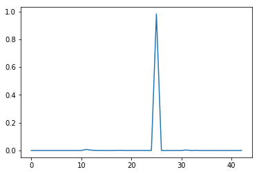

```python
# Top 5 Softmax Probabilities For Image 5:

plt.plot(softmaxs[4])
import tensorflow as tf
with tf.Session() as sess:
    topk = sess.run(tf.nn.top_k((tf.constant(softmaxs[4])), k=5))
print (topk)
```

### Project Writeup

Once you have completed the code implementation, document your results in a project writeup using this [template](https://github.com/udacity/CarND-Traffic-Sign-Classifier-Project/blob/master/writeup_template.md) as a guide. The writeup can be in a markdown or pdf file.

## Step 4 (Optional): Visualize the Neural Network's State with Test Images

This Section is not required to complete but acts as an additional excersise for understaning the output of a neural network's weights. While neural networks can be a great learning device they are often referred to as a black box. We can understand what the weights of a neural network look like better by plotting their feature maps. After successfully training your neural network you can see what it's feature maps look like by plotting the output of the network's weight layers in response to a test stimuli image. From these plotted feature maps, it's possible to see what characteristics of an image the network finds interesting. For a sign, maybe the inner network feature maps react with high activation to the sign's boundary outline or to the contrast in the sign's painted symbol.

Provided for you below is the function code that allows you to get the visualization output of any tensorflow weight layer you want. The inputs to the function should be a stimuli image, one used during training or a new one you provided, and then the tensorflow variable name that represents the layer's state during the training process, for instance if you wanted to see what the LeNet lab's feature maps looked like for it's second convolutional layer you could enter conv2 as the tf_activation variable.

For an example of what feature map outputs look like, check out NVIDIA's results in their paper [End-to-End Deep Learning for Self-Driving Cars](https://devblogs.nvidia.com/parallelforall/deep-learning-self-driving-cars/) in the section Visualization of internal CNN State. NVIDIA was able to show that their network's inner weights had high activations to road boundary lines by comparing feature maps from an image with a clear path to one without. Try experimenting with a similar test to show that your trained network's weights are looking for interesting features, whether it's looking at differences in feature maps from images with or without a sign, or even what feature maps look like in a trained network vs a completely untrained one on the same sign image.

[figure not shown]

Your output should look something like this (above)

```python
### Visualize your network's feature maps here.
### Feel free to use as many code cells as needed.

# image_input: the test image being fed into the network to produce the feature maps
# tf_activation: should be a tf variable name used during your training procedure that represents the calculated state of a specific weight layer
# activation_min/max: can be used to view the activation contrast in more detail, by default matplot sets min and max to the actual min and max values of the output
# plt_num: used to plot out multiple different weight feature map sets on the same block, just extend the plt number for each new feature map entry

def outputFeatureMap(image_input, tf_activation, activation_min=-1, activation_max=-1 ,plt_num=1):
    # Here make sure to preprocess your image_input in a way your network expects
    # with size, normalization, ect if needed
    # image_input =
    # Note: x should be the same name as your network's tensorflow data placeholder variable
    # If you get an error tf_activation is not defined it may be having trouble accessing the variable from inside a function
    activation = tf_activation.eval(session=sess,feed_dict={x : image_input})
    featuremaps = activation.shape[3]
    plt.figure(plt_num, figsize=(15,15))
    for featuremap in range(featuremaps):
        plt.subplot(6,8, featuremap+1) # sets the number of feature maps to show on each row and column
        plt.title('FeatureMap ' + str(featuremap)) # displays the feature map number
        if activation_min != -1 & activation_max != -1:
            plt.imshow(activation[0,:,:, featuremap], interpolation="nearest", vmin =activation_min, vmax=activation_max, cmap="gray")
        elif activation_max != -1:
            plt.imshow(activation[0,:,:, featuremap], interpolation="nearest", vmax=activation_max, cmap="gray")
        elif activation_min !=-1:
            plt.imshow(activation[0,:,:, featuremap], interpolation="nearest", vmin=activation_min, cmap="gray")
        else:
            plt.imshow(activation[0,:,:, featuremap], interpolation="nearest", cmap="gray")
```